# **Part A: Convolutional Neural Network**

## __Previously__

1. Exploratory data analysis was done
2. Original, 31 x 31 and 128 x 128 images was all analysed

## __Import Libraries__

Here is to import all the necessary libraries

```python
# !unzip 1.zip
```

```python
%pip install tensorflow_addons keras-tuner pandas matplotlib seaborn scikit-learn tqdm efficientnet
```

### Other Imports

```python
import numpy as np
import pandas as pd

import seaborn as sns

from matplotlib import pyplot as plt

from sklearn.metrics import classification_report, roc_auc_score, average_precision_score, confusion_matrix, cohen_kappa_score, matthews_corrcoef
from sklearn.metrics import classification_report,accuracy_score, confusion_matrix
from sklearn.decomposition import PCA
from sklearn.preprocessing import Normalizer
from sklearn.metrics import classification_report, accuracy_score

import os, time, math, datetime, warnings, pytz, glob
from IPython.display import display
from functools import reduce
import absl.logging
from tqdm import tqdm
import logging
from efficientnet.tfkeras import EfficientNetB3

absl.logging.set_verbosity(absl.logging.ERROR)
logging.getLogger('tensorflow').disabled = True
warnings.filterwarnings('ignore')
```

### Tensorflow Import

```python
import tensorflow as tf
from tensorflow.keras.utils import Sequence, to_categorical
from tensorflow import expand_dims
from tensorflow.keras import Sequential
from tensorflow.keras import layers as L
from tensorflow.keras import backend as K
from tensorflow.image import random_flip_left_right, random_crop, resize_with_crop_or_pad
from tensorflow.keras.utils import to_categorical, plot_model
from tensorflow.keras.models import Model, load_model
from tensorflow.keras.layers import (Dense, Input, InputLayer, Normalization, Flatten,BatchNormalization,
    Dropout,Conv2D, GlobalAveragePooling2D, MaxPooling2D, ReLU, Layer,Activation, Multiply, AveragePooling2D,
    Add, RandomRotation,Resizing, Rescaling, Reshape, Concatenate, concatenate, Lambda,LeakyReLU, ZeroPadding2D)
from tensorflow.keras.callbacks import EarlyStopping, ModelCheckpoint, LearningRateScheduler, ReduceLROnPlateau, TerminateOnNaN, TensorBoard, CSVLogger, Callback
from tensorflow.keras.backend import clear_session
from tensorflow.keras.optimizers import RMSprop, SGD, Adam, Adagrad, Adamax
from tensorflow.keras.regularizers import l2, L2
from tensorflow.keras.optimizers.schedules import *
from tensorflow.keras.metrics import FalseNegatives, categorical_crossentropy, sparse_categorical_crossentropy
from tensorflow.keras.losses import CategoricalCrossentropy
from tensorflow.keras.preprocessing.image import ImageDataGenerator
from tensorflow.image import *
from tensorflow_addons.optimizers import SWA
from tensorflow.keras import layers

from kerastuner.tuners import Hyperband
from kerastuner import RandomSearch
from kerastuner import HyperModel
# Setting a seaborn style
sns.set(style="whitegrid")
```

### Set the seed of this notebook

```python
seed = 32
tf.random.set_seed(seed)
np.random.seed(seed)
```

## __Check for GPU__

Here is check the available GPUs and set the memory growth

```python
gpus = tf.config.experimental.list_physical_devices('GPU')
if gpus:
    try:
        for gpu in gpus:
            tf.config.experimental.set_memory_growth(gpu, True)

        logical_gpus = tf.config.experimental.list_logical_devices('GPU')
        print(f"{len(gpus)} Physical GPUs, {len(logical_gpus)} Logical GPU")
    except RuntimeError as e:
        print(e)
```

```
1 Physical GPUs, 1 Logical GPU
```

```python
!nvidia-smi
```

```
Sun Nov 26 00:46:23 2023
+---------------------------------------------------------------------------------------+
| NVIDIA-SMI 535.113.01             Driver Version: 535.113.01   CUDA Version: 12.2     |
|-----------------------------------------+----------------------+----------------------+
| GPU  Name                 Persistence-M | Bus-Id        Disp.A | Volatile Uncorr. ECC |
| Fan  Temp   Perf          Pwr:Usage/Cap |         Memory-Usage | GPU-Util  Compute M. |
|                                         |                      |               MIG M. |
|=========================================+======================+======================|
|   0  NVIDIA GeForce RTX 4090        On  | 00000000:01:00.0 Off |                  Off |
|  0%   37C    P2              46W / 450W |    548MiB / 24564MiB |      3%      Default |
|                                         |                      |                  N/A |
+-----------------------------------------+----------------------+----------------------+

+---------------------------------------------------------------------------------------+
| Processes:                                                                            |
|  GPU   GI   CI        PID   Type   Process name                            GPU Memory |
|        ID   ID                                                             Usage      |
|=======================================================================================|
+---------------------------------------------------------------------------------------+
```

## __Import dataset__

Here is to import the dataset and proceed to do analysis on it

### 31 x 31 Images

#### Train Data

```python
data_small = tf.keras.utils.image_dataset_from_directory('Dataset for CA1 part A/train'  ,
                                                   color_mode='rgb',
                                                   image_size=(31,31))
data_small
```

```
Found 9028 files belonging to 15 classes.
```

```
<BatchDataset element_spec=(TensorSpec(shape=(None, 31, 31, 3), dtype=tf.float32, name=None), TensorSpec(shape=(None,), dtype=tf.int32, name=None))>
```

```python
X_train_small = []
y_train_small = []

for images, labels in tqdm(data_small):
    images = tf.image.rgb_to_grayscale(images)
    X_train_small.append(images)
    y_train_small.append(labels)

X_train_small = np.concatenate(X_train_small, axis=0)
X_train_small = np.squeeze(X_train_small, axis=-1)
y_train_small = np.concatenate(y_train_small, axis=0)
```

#### Validation Data

```python
val_data_small = tf.keras.utils.image_dataset_from_directory('Dataset for CA1 part A/validation'  ,
                                                   color_mode='rgb',
                                                   image_size=(31,31))
val_data_small
```

```
Found 3000 files belonging to 15 classes.
```

```
<BatchDataset element_spec=(TensorSpec(shape=(None, 31, 31, 3), dtype=tf.float32, name=None), TensorSpec(shape=(None,), dtype=tf.int32, name=None))>
```

```python
X_val_small = []
y_val_small = []

for images, labels in tqdm(val_data_small):
    images = tf.image.rgb_to_grayscale(images)
    X_val_small.append(images)
    y_val_small.append(labels)

X_val_small = np.concatenate(X_val_small, axis=0)
X_val_small = np.squeeze(X_val_small, axis=-1)
y_val_small = np.concatenate(y_val_small, axis=0)
```

#### Test Data

```python
test_data_small = tf.keras.utils.image_dataset_from_directory('Dataset for CA1 part A/test'  ,
                                                   color_mode='rgb',
                                                   image_size=(31,31))
test_data_small
```

```
Found 3000 files belonging to 15 classes.
```

```
<BatchDataset element_spec=(TensorSpec(shape=(None, 31, 31, 3), dtype=tf.float32, name=None), TensorSpec(shape=(None,), dtype=tf.int32, name=None))>
```

```python
X_test_small = []
y_test_small = []

for images, labels in tqdm(test_data_small):
    images = tf.image.rgb_to_grayscale(images)
    X_test_small.append(images)
    y_test_small.append(labels)

X_test_small = np.concatenate(X_test_small, axis=0)
X_test_small = np.squeeze(X_test_small, axis=-1)
y_test_small = np.concatenate(y_test_small, axis=0)
```

```python
labels_dict = os.listdir('Dataset for CA1 part A/train')
labels_dict = {idx: label for idx, label in enumerate(labels_dict)}
print(labels_dict)
```

```
{0: 'Bean', 1: 'Bitter_Gourd', 2: 'Bottle_Gourd', 3: 'Brinjal', 4: 'Broccoli', 5: 'Cabbage', 6: 'Capsicum', 7: 'Carrot', 8: 'Cauliflower', 9: 'Cucumber', 10: 'Papaya', 11: 'Potato', 12: 'Pumpkin', 13: 'Radish', 14: 'Tomato'}
```

## __Data Preprocessing (Basic)__

Here we will do the basic data preprocessing

### Mean Normalisation

$$ X_{} = \frac{x_{} - μ_{}}{σ_{}} $$

Where:

- `X` is the scaled value after normalisation
- `x` is the original value of the feature
- `μ` is the mean value
- `σ` is the standard deviation

This ensures that all the data will have the same influence with it beiung on the similar scale

```python
preprocess = Normalization()
preprocess.adapt(X_train_small)
after = tf.squeeze(preprocess(X_train_small[:1,:,:]))
after
```

[output not shown]

[output cut: 163 more lines]

[output not shown]

#### Comparing the difference

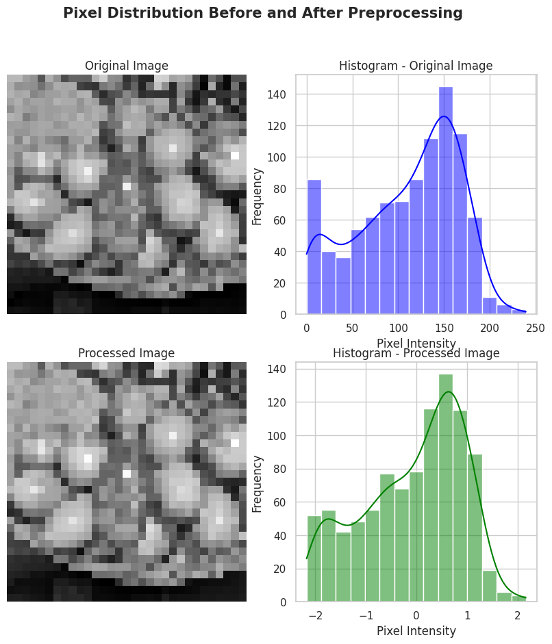

```python
fig, ax = plt.subplots(2, 2, figsize=(10, 10))
fig.suptitle('Pixel Distribution Before and After Preprocessing', fontsize=15, fontweight='bold')

ax[0, 0].set_title('Original Image')
ax[0, 0].imshow(X_train_small[0].astype(np.uint8), cmap='gray')
ax[0, 0].axis('off')

ax[0, 1].set_title('Histogram - Original Image')
sns.histplot(X_train_small[0].flatten(), ax=ax[0, 1], color='blue', kde=True)
ax[0, 1].set_xlabel('Pixel Intensity')
ax[0, 1].set_ylabel('Frequency')
ax[0, 1].grid(True)

ax[1, 0].set_title('Processed Image')
ax[1, 0].imshow(after, cmap='gray')
ax[1, 0].axis('off')

ax[1, 1].set_title('Histogram - Processed Image')
sns.histplot(after.numpy().flatten(), ax=ax[1, 1], color='green', kde=True)
ax[1, 1].set_xlabel('Pixel Intensity')
ax[1, 1].set_ylabel('Frequency')
ax[1, 1].grid(True)

plt.show()
```

*Things Observed*

- Above, we can see how the image look after utilising data preprocessing mean normlisation

### Encoding

- Tensorflow to categorical fuunction helps tonverts the data into integer of 0 and 1 similar to that of a one hot encoding
- We will proceed to encode the y into one hot encoding with training

```python
y_train_small = to_categorical(y_train_small)
y_val_small = to_categorical(y_val_small)
```

#### Check on the encoding shape here|

```python
y_train_small.shape, y_val_small.shape
```

```
((9028, 15), (3000, 15))
```

*Things Observed*

- The one hot encoding is done accurately with 15 classes for each y labels

## __WandDB__

Store the model into a cloud service

```python
!pip install wandb -qU
```

```python
import wandb
wandb.login()
# 6f7550f0407bb56d822df6618b5721c40a68a3dd
```

```
Failed to detect the name of this notebook, you can set it manually with the WANDB_NOTEBOOK_NAME environment variable to enable code saving.
wandb: Currently logged in as: ruizhuo168 (111da). Use `wandb login --relogin` to force relogin
```

```
True
```

```python
from wandb.keras import WandbCallback
```

## __Required Functions__

### Loss and Accuracy Curve

1. Loss Curve:
   - Calculates the actual difference between the model's prediction and the actual true output
   - By minimising the loss, the model aims to make its predictions as close as possible to the true value
   - Shows us the loss over iterations

[figure not shown]

2. Accuracy Curve:
   - This us how good the model is at making correct predictions on the training data as it goes through the training process.
   - It is measured in percentages and tells us the proportion of instances the model correctly classified out of the total number of instances
   - Tells us how well the model fit with the data

[figure not shown]

```python
def plot_model_history(model_history):
    history_df = pd.DataFrame(model_history)
    fig, axs = plt.subplots(1, 2, figsize=(14, 5))

    axs[0].plot(history_df['loss'], 'g--', label='Training Loss')
    axs[0].plot(history_df['val_loss'], 'b-', label='Validation Loss')
    axs[0].set_title('Training and Validation Loss')
    axs[0].set_xlabel('Epochs')
    axs[0].set_ylabel('Loss')
    axs[0].legend()
    axs[0].grid(True)

    if 'accuracy' in history_df and 'val_accuracy' in history_df:
        axs[1].plot(history_df['accuracy'], 'g--', label='Training Accuracy')
        axs[1].plot(history_df['val_accuracy'], 'b-', label='Validation Accuracy')
        axs[1].set_title('Training and Validation Accuracy')
        axs[1].set_xlabel('Epochs')
        axs[1].set_ylabel('Accuracy')
        axs[1].legend()
        axs[1].grid(True)

    plt.tight_layout()
    plt.close(fig)

    def show():
        display(fig)

    return show
```

### Setting up the parameters

```python
LR = 0.01
MOMENTUM = 0.9
WEIGHT_DECAY = 0.0005
val_split = 0.2
max_epochs = 100
```

```python
base_hparams = {"val_split" : val_split, "max_epochs" : max_epochs,"batch_size" : 128}
steps_per_epoch = np.ceil(len(X_train_small) / 128)
steps_per_epoch
```

```
71.0
```

### Evluator

- Evaluator class will handle the data and history
- Training of model
- Return history and defined callbacks

```python
class Evaluator:
  def __init__(self, path=None, project_name="CNN_CA1"):
      # Initialize wandb
      self.project_name = project_name

      # Your existing initialization code
      if path:
          self.result = pd.read_csv(path, sep=';')
      else:
          cols = ['Model Name', 'Batch Size', "Train Loss", "Test Loss", "Train Acc", "Test Acc", "Remarks"]
          self.result = pd.DataFrame(columns=cols)

      self.callback = [
          TerminateOnNaN()
      ]
      # self.api = wandb.Api()

  def train_model(self, model, train, val, hyperparameters, callbacks):
    tf.keras.backend.clear_session()
    epochs = hyperparameters['max_epochs']
    batch_size = 64

    if val is None:
      X_train, y_train = train
      return model.fit(X_train, y_train, epochs=epochs, batch_size=64, validation_split = hyperparameters["val_split"], callbacks=callbacks).history
    else:
      return model.fit(train, validation_data = val, epochs = epochs, batch_size = batch_size , callbacks=callbacks).history

  def model_evaluate(self, train, val, model, hyperparameters, callbacks=None, plot_loss=True, remarks=""):
      tf.keras.backend.clear_session()
      # wandb.init(project=self.project_name)
      callbacks = (callbacks or [EarlyStopping(monitor='val_accuracy', patience=10, restore_best_weights=True), ReduceLROnPlateau(patience=5)]) + self.callback
      history = self.train_model(model, train, val, hyperparameters, callbacks)
      bestval_index = np.argmax(history['val_accuracy'])


      if plot_loss:
          try:
              fig = plot_model_history(history)
          except Exception as e:
              print(e, 'here')
              print("error creating loss curve")
              fig = None

      result = {
          "Model Name": model.name,
          "Epochs": len(history["loss"]),
          "Batch Size": hyperparameters["batch_size"],
          "Train Loss": history["loss"][bestval_index],
          "Test Loss": history["val_loss"][bestval_index],
          "Train Acc": history["accuracy"][bestval_index],
          "Test Acc": history["val_accuracy"][bestval_index]
      }
      # wandb.log({
      #     "Model Name": model.name,
      #     "Epochs": len(history["loss"]),
      #     "Batch Size": hyperparameters["batch_size"],
      #     "Train Loss": history["loss"][bestval_index],
      #     "Test Loss": history["val_loss"][bestval_index],
      #     "Train Acc": history["accuracy"][bestval_index],
      #     "Test Acc": history["val_accuracy"][bestval_index],
      # })

      # wandb.finish()
      return result, fig

  def _train_model(self, model, training_data, validation_data, hyperparameters, callbacks):
      tf.keras.backend.clear_session()
      epochs = hyperparameters["max_epochs"]
      batch_size = hyperparameters["batch_size"]

      if validation_data is None:
          X_train, y_train = training_data
          return model.fit(X_train, y_train, epochs=epochs, batch_size=batch_size, validation_split=hyperparameters["val_split"], callbacks=callbacks).history

      return model.fit(training_data, validation_data=validation_data, epochs=epochs, batch_size=batch_size, callbacks=callbacks).history


  def return_history(self, project_name='CNN_CA1', entity=None, include_cols=None):
      if include_cols is None:
          include_cols = ['Model Name', 'Epochs', 'Batch Size', 'Train Loss','Test Loss','Train Acc','Test Acc','Remarks']

      runs = self.api.runs('111da/CNN_CA1')
      # List to store results
      results = []

      for run in runs:
          run_summary = run.summary
          data = {}
          for col in include_cols:
              data[col] = run_summary.get(col, None)
          results.append(data)
      df = pd.DataFrame(results)

      return df


  def remove_model(self, model_name):
      self.result = self.result[self.result["Model Name"] != model_name]
```

### Evaluation Function

- Below is a function for evluation
- Dataframe with classification report showing different evaluation metric

```python
def evaluation_test(model, X_val, y_val, LABELS):
    final_predictions = model.predict(X_val)
    final_predictions_final = np.argmax(final_predictions, axis=1)
    y_test_final = np.argmax(y_val, axis=1) if y_val.ndim == 2 else y_val
    classification_results = classification_report(y_test_final, final_predictions_final, target_names=LABELS.values(), output_dict=True)

    # Print Accuracy
    print('Accuracy:', accuracy_score(y_test_final, final_predictions_final))
    result = pd.DataFrame(classification_results).transpose().sort_values('f1-score')
    return result
```

### HeatMap Visualisation

- This function is too visualise heatmap
- The graph will show the different scores

```python
def plot_classification_heatmap(df):
    heatmap_data = df.drop(['accuracy', 'macro avg', 'weighted avg']).iloc[:, :-1]
    plt.figure(figsize=(10, 8))
    sns.heatmap(heatmap_data, annot=True, fmt=".2f", cmap="Blues")
    plt.title("Classification Report Heatmap")
    plt.show()
```

## __Evaluation Metrics__

Below are the evaluation metrics that I am going to be using

### Accuracy

- Measure of how often the model correctly predicts the label of input data

### Validation Accuracy

- This is similar to accuracy but is calculate on validation data to show us how weel the model is doing

### Loss

- Measure of the error between predicted and actual values (Eg: Categoryical Cross entropy)

### Validation Loss

- Similar to Loss but test on validation set to show how is the model doing

### Confusuion Matrix on F1-Score, Precision, Recall

- Includes a summary of how well the model is doling with respect to classes and diferent evaluation metric in classification task

### Cohen Kappa

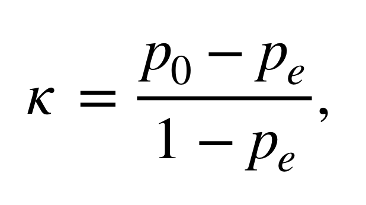

- Statistical Analysis that adjust for the agreement
  - Values ≤ 0 suggest no agreement
  - 0.01–0.20 indicates slight agreement
  - 0.21–0.40 indicates fair agreement
  - 0.41–0.60 indicates moderate agreement
  - 0.61–0.80 indicates substantial agreement
  - 0.81–1.00 indicates almost perfect agreement
- Specifically useful for imbalance datasetment.

## __Baseline Model__

Here, we will creaate a few baseliune model

1. First part will be custom implementation
2. Second part will be implementation of trained models

### Making the Train and Validation Data

```python
no = lambda x : x
def data_before_train(self, aug_func=no):
    train_ds = tf.data.Dataset.from_tensor_slices((X_train_small, y_train_small)).map(lambda x, y : (expand_dims(x, -1), y))
    val_ds = tf.data.Dataset.from_tensor_slices((X_val_small, y_val_small)).shuffle(128 * 100).batch(128).map(lambda x, y : (expand_dims(x, -1), y)).prefetch(tf.data.AUTOTUNE)
    train_ds = train_ds.map(lambda x, y : (aug_func(x), y), num_parallel_calls=tf.data.AUTOTUNE).shuffle(128 * 100).batch(128).prefetch(tf.data.AUTOTUNE)
    return train_ds, val_ds
train_ds, val_ds = data_before_train(no)
```

### Making the results dataframe

```python
columns = ["Model Name", "Epochs", "Batch Size", "Train Loss", "Test Loss", "Train Acc", "Test Acc",'Kappa', "Comments"]
overall = pd.DataFrame(columns=columns)
print(overall)
```

```
Empty DataFrame
Columns: [Model Name, Epochs, Batch Size, Train Loss, Test Loss, Train Acc, Test Acc, Kappa, Comments]
Index: []
```

### Dense Neural Network Model

**Input Type**

- **Configuration**: Shape (31, 31, 1)

**Flatten**

- **Purpose**: Flattens the 2D input image into a 1D array

**First, Second**

**Third Dense Block:**

- **Layer Type**: Dense with 64 neurons and activation: ReLU
- **Layer Type**: BatchNormalization
- **Layer Type**: LeakyReLU
- **Layer Type**: Dropout

**Output**

- **Layer Type**: Dense with 15 neurons and activation: Softmax

**Compilation**

```python
def baseline_model(optimizer='adam', name='Baseline_Dense_Model'):
    model = Sequential(name=name)

    model.add(Input(shape=(31, 31, 1)))
    model.add(preprocess)
    model.add(Flatten())

    # First Dense Block
    model.add(Dense(64, activation='relu'))
    model.add(BatchNormalization())
    model.add(LeakyReLU())
    model.add(Dropout(0.2))

    # Second Dense block
    model.add(Dense(64, activation='relu'))
    model.add(BatchNormalization())
    model.add(LeakyReLU())
    model.add(Dropout(0.2))

    # Third dense block
    model.add(Dense(64, activation='relu'))
    model.add(BatchNormalization())
    model.add(LeakyReLU())
    model.add(Dropout(0.2))

    # Output
    model.add(Dense(15, activation='softmax'))

    # Compile the model
    model.compile(optimizer=optimizer, loss='categorical_crossentropy', metrics=['accuracy'])
    model.summary()

    return model
```

#### Setting up the evaluator

```python
evaluator = Evaluator()
```

#### Running the model

```python
model = baseline_model()
results_base, fig_base = evaluator.model_evaluate( train_ds, val_ds , model, base_hparams)
```

```
Model: "Baseline_Dense_Model"
_________________________________________________________________
 Layer (type)                Output Shape              Param #
=================================================================
 normalization (Normalizatio  (None, 31, 31, 31)       63
 n)

 flatten (Flatten)           (None, 29791)             0

 dense (Dense)               (None, 64)                1906688

 batch_normalization (BatchN  (None, 64)               256
 ormalization)

 leaky_re_lu (LeakyReLU)     (None, 64)                0

 dropout (Dropout)           (None, 64)                0

 dense_1 (Dense)             (None, 64)                4160

 batch_normalization_1 (Batc  (None, 64)               256
 hNormalization)

 leaky_re_lu_1 (LeakyReLU)   (None, 64)                0

 dropout_1 (Dropout)         (None, 64)                0

 dense_2 (Dense)             (None, 64)                4160

 batch_normalization_2 (Batc  (None, 64)               256
 hNormalization)

 leaky_re_lu_2 (LeakyReLU)   (None, 64)                0

 dropout_2 (Dropout)         (None, 64)                0

 dense_3 (Dense)             (None, 15)                975

=================================================================
Total params: 1,916,814
Trainable params: 1,916,367
Non-trainable params: 447
_________________________________________________________________
```

#### Analysing the graph

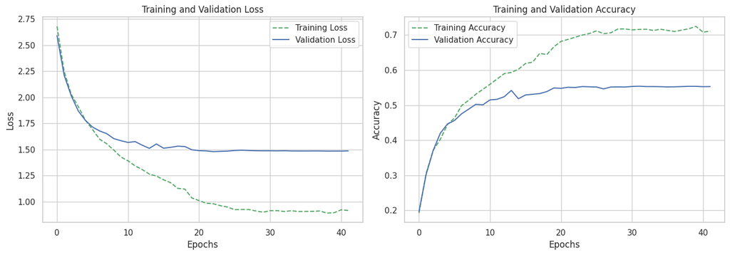

```python
fig_base()
```

```python
pd.Series(results_base)
```

```
Model Name    Baseline_Dense_Model
Epochs                          42
Batch Size                     128
Train Loss                0.914943
Test Loss                 1.486889
Train Acc                 0.715884
Test Acc                     0.554
dtype: object
```

*Things Observed*

- Training and Validation loss  
 - For the training loss, it starts relatively high and drops quickly and continues to decrease steadily as the epochs increases  
 - For the validation loss, similar patterns occur with the okatueay without increasing but a relatively higher loss  
- Training and Validation accuracy  
 - For the training accuracy, it increases sharply at the beginning and continues to increase gradually, indicates effective lerarning  
 - For the validation accuracy, similar pattern is seen but with a relatveily lower accuracy here

#### Evaluation on test set

- This is to check for overfitting
- And also how the model performs with respect to each classes

```python
cls_df_base = evaluation_test(model, X_test_small, y_test_small, labels_dict)
cls_df_base
```

```
Accuracy: 0.5593333333333333
```

|  | precision | recall | f1-score | support |
| --- | --- | --- | --- | --- |
| Cabbage | 0.496894 | 0.400000 | 0.443213 | 200.000000 |
| Tomato | 0.379412 | 0.645000 | 0.477778 | 200.000000 |
| Bean | 0.423221 | 0.565000 | 0.483940 | 200.000000 |
| Broccoli | 0.458874 | 0.530000 | 0.491879 | 200.000000 |
| Potato | 0.616541 | 0.410000 | 0.492492 | 200.000000 |
| Radish | 0.720339 | 0.425000 | 0.534591 | 200.000000 |
| Carrot | 0.773585 | 0.410000 | 0.535948 | 200.000000 |
| Cauliflower | 0.576087 | 0.530000 | 0.552083 | 200.000000 |
| accuracy | 0.559333 | 0.559333 | 0.559333 | 0.559333 |
| macro avg | 0.589781 | 0.559333 | 0.559844 | 3000.000000 |
| weighted avg | 0.589781 | 0.559333 | 0.559844 | 3000.000000 |
| Bitter_Gourd | 0.526316 | 0.650000 | 0.581655 | 200.000000 |
| Pumpkin | 0.547325 | 0.665000 | 0.600451 | 200.000000 |
| Capsicum | 0.784000 | 0.490000 | 0.603077 | 200.000000 |
| Brinjal | 0.567797 | 0.670000 | 0.614679 | 200.000000 |
| Papaya | 0.621005 | 0.680000 | 0.649165 | 200.000000 |
| Cucumber | 0.661765 | 0.675000 | 0.668317 | 200.000000 |
| Bottle_Gourd | 0.693548 | 0.645000 | 0.668394 | 200.000000 |

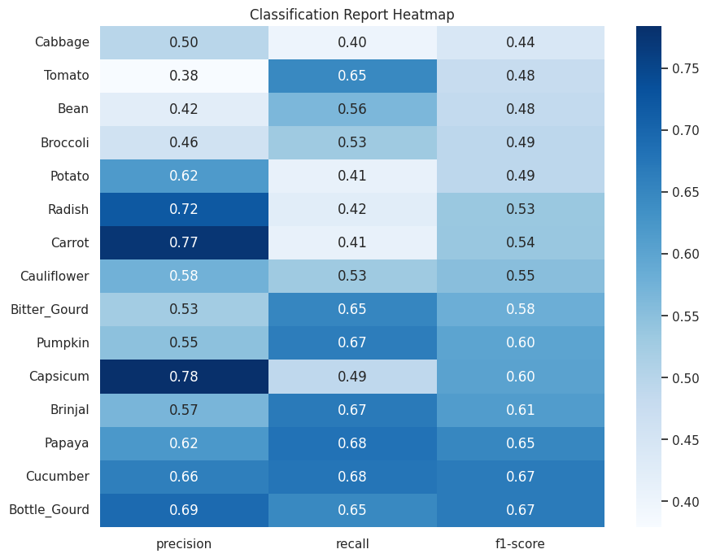

```python
plot_classification_heatmap(cls_df_base)
```

*Things Observed*

#### Cohen Kappa Coefficient

```python
y_pred = model.predict(X_test_small)
y_pred_classes = np.argmax(y_pred, axis=1)
kappa_base = cohen_kappa_score(y_test_small, y_pred_classes)
print("Cohen’s Kappa Score:", kappa_base)
```

```
Cohen’s Kappa Score: 0.5278571428571428
```

*Things Observed*

Adding in the results to the overall dataframe

```python
results_base['Kappa'] = kappa_base
overall = pd.concat([overall, pd.DataFrame([results_base])], ignore_index=True)
overall
```

|  | Model Name | Epochs | Batch Size | Train Loss | Test Loss | Train Acc | Test Acc | Kappa | Comments |
| --- | --- | --- | --- | --- | --- | --- | --- | --- | --- |
| 0 | Baseline_Dense_Model | 42 | 128 | 0.914943 | 1.486889 | 0.715884 | 0.554 | 0.527857 | NaN |

### Convolutional Neural Network Model

**Input Layer**

- Configuration: Shape (31, 31, 1)

**Convolutional Blocks**

**Flattening**

- Transition from 3D output of Conv blocks to 1D array.

**Dense Layers**

- Two dense blocks with 512 and 128 neurons, ReLU activation, BatchNormalization, and Dropout (0.5 for both).

**Output Layer**

- Dense with 15 neurons, Softmax activation for multi-class classification.

**Compilation**

```python
def baseline_model2(optimizer='adam', name='CNN_Baseline'):
    model = Sequential(name=name)

    # Input layer
    model.add(Input(shape=(31, 31, 1)))

    # First Convolutional Block
    model.add(Conv2D(64, (3, 3), padding='same', activation='relu'))
    model.add(BatchNormalization())
    model.add(MaxPooling2D(pool_size=(2, 2)))
    model.add(Dropout(0.3))

    # Second Convolutional Block
    model.add(Conv2D(128, (3, 3), padding='same', activation='relu'))
    model.add(BatchNormalization())
    model.add(MaxPooling2D(pool_size=(2, 2)))
    model.add(Dropout(0.3))

    model.add(Flatten())

    # Dense Block
    model.add(Dense(512, activation='relu'))
    model.add(BatchNormalization())
    model.add(Dropout(0.5))

    # Dense Block
    model.add(Dense(128, activation='relu'))
    model.add(BatchNormalization())
    model.add(Dropout(0.5))

    # Output Layer
    model.add(Dense(15, activation='softmax'))

    # Compile the model
    model.compile(optimizer=optimizer, loss='categorical_crossentropy', metrics=['accuracy'])

    model.summary()

    return model
```

#### Running the model

```python
cnn_model = baseline_model2()
results_cnn, fig_cnn = evaluator.model_evaluate( train_ds, val_ds , cnn_model, base_hparams)
```

```
Model: "CNN_Baseline"
_________________________________________________________________
 Layer (type)                Output Shape              Param #
=================================================================
 conv2d (Conv2D)             (None, 31, 31, 64)        640

 batch_normalization (BatchN  (None, 31, 31, 64)       256
 ormalization)

 max_pooling2d (MaxPooling2D  (None, 15, 15, 64)       0
 )

 dropout (Dropout)           (None, 15, 15, 64)        0

 conv2d_1 (Conv2D)           (None, 15, 15, 128)       73856

 batch_normalization_1 (Batc  (None, 15, 15, 128)      512
 hNormalization)

 max_pooling2d_1 (MaxPooling  (None, 7, 7, 128)        0
 2D)

 dropout_1 (Dropout)         (None, 7, 7, 128)         0

 flatten (Flatten)           (None, 6272)              0

 dense (Dense)               (None, 512)               3211776

 batch_normalization_2 (Batc  (None, 512)              2048
 hNormalization)

 dropout_2 (Dropout)         (None, 512)               0

 dense_1 (Dense)             (None, 128)               65664

 batch_normalization_3 (Batc  (None, 128)              512
 hNormalization)

 dropout_3 (Dropout)         (None, 128)               0

 dense_2 (Dense)             (None, 15)                1935

=================================================================
Total params: 3,357,199
Trainable params: 3,355,535
Non-trainable params: 1,664
_________________________________________________________________
```

#### Analysing the graph

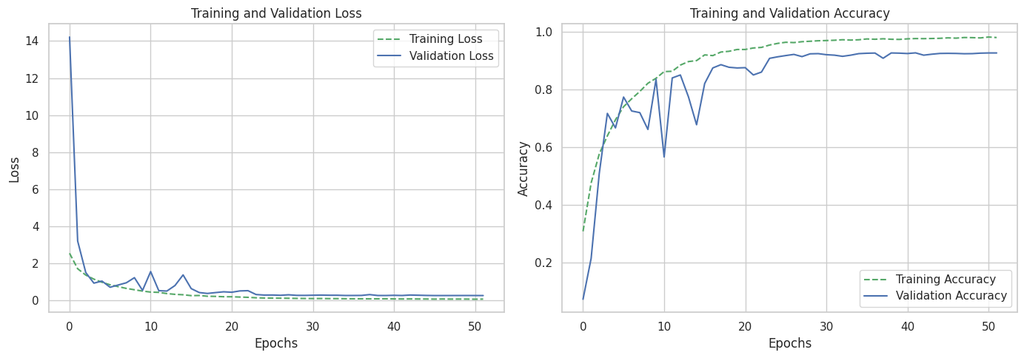

```python
fig_cnn()
```

```python
pd.Series(results_cnn)
```

```
Model Name    CNN_Baseline
Epochs                  52
Batch Size             128
Train Loss         0.07441
Test Loss         0.261325
Train Acc         0.976961
Test Acc          0.927333
dtype: object
```

*Things Observed*

- Training and Validation loss  
 - For the training loss, it starts relatively high and drops quickly and continues to decrease steadily as the epochs increases  
 - For the validation loss, similar patterns occur with the okatueay without increasing but a relatively higher loss but noticeble spikes were seen at the start before plateau and may have some form of overfitting  
- Training and Validation accuracy  
 - For the training accuracy, it increases sharply at the beginning and continues to increase gradually, indicates effective lerarning  
 - For the validation accuracy, similar pattern is seen but with a relatveily lower accuracy here and noticeable downward spikes which similarly could suggest overfitting

#### Evaluation on test set

- This is to check for overfitting
- And also how the model performs with respect to each classes

```python
cls_df_cnn = evaluation_test(cnn_model, X_test_small, y_test_small, labels_dict)
```

```
Accuracy: 0.9296666666666666
```

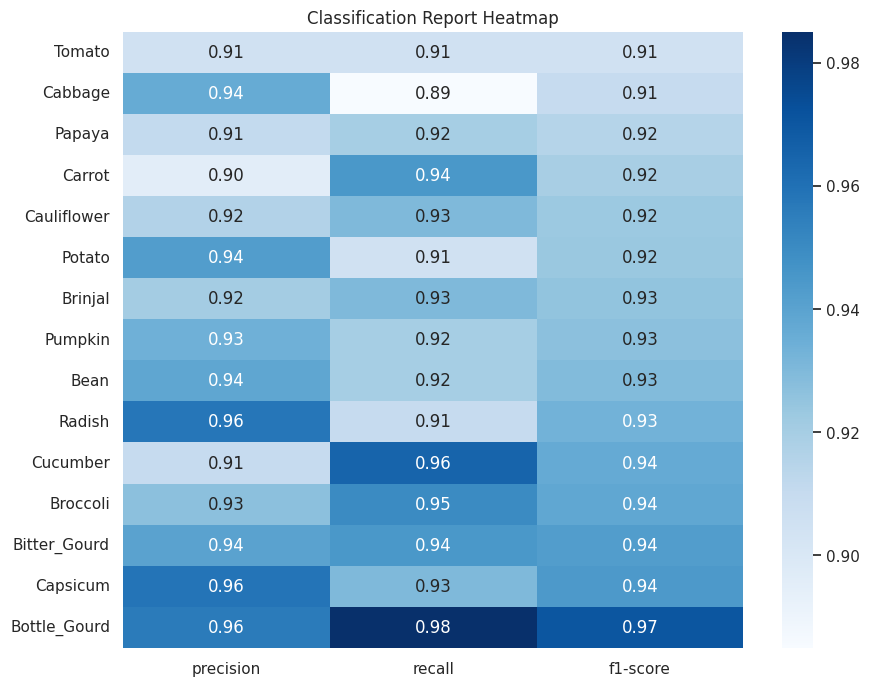

```python
plot_classification_heatmap(cls_df_cnn)
```

*Things Observed*

### Cohen Kappa Coefficient

```python
y_pred = cnn_model.predict(X_test_small)
y_pred_classes = np.argmax(y_pred, axis=1)
kappa_cnn = cohen_kappa_score(y_test_small, y_pred_classes)
print("Cohen’s Kappa Score:", kappa_cnn)
```

```
Cohen’s Kappa Score: 0.9246428571428571
```

*Things Observed*

- From the Cophen Kappa Coefficient, we can see that the model is reliable and good

Adding results to dataframe

```python
results_cnn['Kappa'] = kappa_cnn
overall = pd.concat([overall, pd.DataFrame([results_cnn])], ignore_index=True)
overall
```

|  | Model Name | Epochs | Batch Size | Train Loss | Test Loss | Train Acc | Test Acc | Kappa | Comments |
| --- | --- | --- | --- | --- | --- | --- | --- | --- | --- |
| 0 | Baseline_Dense_Model | 42 | 128 | 0.914943 | 1.486889 | 0.715884 | 0.554000 | 0.527857 | NaN |
| 1 | CNN_Baseline | 52 | 128 | 0.074410 | 0.261325 | 0.976961 | 0.927333 | 0.924643 | NaN |

### Baseline Model 3 Creation (Second CNN)

Compared to previous CNN Input Layer

- **Configuration**: Accepts `(31, 31, 1)`

First Few CNN Bock

Three more Conv Blocks

- **Layers**: Three additional convolutional blocks, each with `128` filters
- **Kernel Size**: `(3, 3)` kernel size
- **Padding**: 'same' padding to avoid reduction in dimensionality
- **Normalization and Activation**: Followed by batch normalization and ReLU activation

Global Average Pooling

- **Layer**: GlobalAveragePooling2D is used to condense feature maps into a single vector per map

Dense Layers for Classification

- **Dense Layer**: Dense layer with `256` neurons and ReLU activation
- **Output Layer**: Final output layer with `15` neurons

Compilation

```python
def CNN2(name='CNN2_Baseline'):

    filters_list = [ 128, 128, 128]

    model = Sequential()

    # Add initial convolutional layers
    model.add(Conv2D(filters=filters_list[0], kernel_size=(3, 3), padding='same', input_shape=(31, 31, 1)))
    model.add(BatchNormalization())
    model.add(ReLU())

    model.add(Conv2D(filters=filters_list[1], kernel_size=(3, 3), padding='same'))
    model.add(BatchNormalization())
    model.add(ReLU())

    for filters in filters_list:
        model.add(Conv2D(filters=filters, kernel_size=(3, 3), padding='same'))
        model.add(BatchNormalization())
        model.add(ReLU())

    model.add(GlobalAveragePooling2D())
    model.add(Dense(256, activation='relu'))
    model.add(Dense(15, activation='softmax'))

    model.compile(optimizer='adam', loss='categorical_crossentropy', metrics=['accuracy'])
    model.summary()
    return model
```

#### Running the model -- Reduce Complexity

```python
import os
os.environ['TF_GPU_ALLOCATOR'] = 'cuda_malloc_async'
import tensorflow as tf
cnn_model2 = CNN2()
results_cnn2, fig_cnn2 = evaluator.model_evaluate( train_ds, val_ds , cnn_model2, base_hparams)
```

```
Model: "sequential"
_________________________________________________________________
 Layer (type)                Output Shape              Param #
=================================================================
 conv2d (Conv2D)             (None, 31, 31, 128)       1280

 batch_normalization (BatchN  (None, 31, 31, 128)      512
 ormalization)

 re_lu (ReLU)                (None, 31, 31, 128)       0

 conv2d_1 (Conv2D)           (None, 31, 31, 128)       147584

 batch_normalization_1 (Batc  (None, 31, 31, 128)      512
 hNormalization)

 re_lu_1 (ReLU)              (None, 31, 31, 128)       0

 conv2d_2 (Conv2D)           (None, 31, 31, 128)       147584

 batch_normalization_2 (Batc  (None, 31, 31, 128)      512
 hNormalization)

 re_lu_2 (ReLU)              (None, 31, 31, 128)       0

 conv2d_3 (Conv2D)           (None, 31, 31, 128)       147584

 batch_normalization_3 (Batc  (None, 31, 31, 128)      512
 hNormalization)

 re_lu_3 (ReLU)              (None, 31, 31, 128)       0

 conv2d_4 (Conv2D)           (None, 31, 31, 128)       147584

 batch_normalization_4 (Batc  (None, 31, 31, 128)      512
 hNormalization)

 re_lu_4 (ReLU)              (None, 31, 31, 128)       0

 global_average_pooling2d (G  (None, 128)              0
 lobalAveragePooling2D)

 dense (Dense)               (None, 256)               33024

 dense_1 (Dense)             (None, 15)                3855

=================================================================
Total params: 631,055
Trainable params: 629,775
Non-trainable params: 1,280
_________________________________________________________________
```

#### Analysing the graph

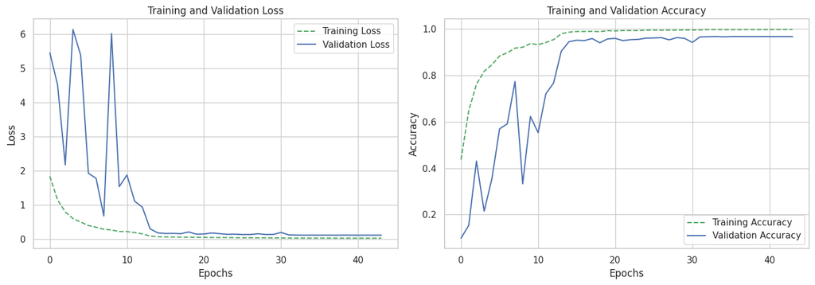

```python
fig_cnn2()
```

```python
pd.Series(results_cnn2)
```

```
Model Name    sequential
Epochs                44
Batch Size           128
Train Loss      0.025112
Test Loss       0.111673
Train Acc       0.998006
Test Acc           0.968
dtype: object
```

*Things Observed*

- Training and Validation loss  
 - For the training loss, it starts relatively high and drops quickly and continues to decrease steadily as the epochs increases  
 - For the validation loss, similar patterns occur with the okatueay without increasing but a relatively higher loss but noticeble spikes seen at the start but proceeds to consistent later on  
- Training and Validation accuracy  
 - For the training accuracy, it increases sharply at the beginning and continues to increase gradually, indicates effective lerarning  
 - For the validation accuracy, similar pattern is seen but with a relatveily lower accuracy here and noticeable downward spikes at the start before steadily increasing

#### Evaluation on test set

- This is to check for overfitting
- And also how the model performs with respect to each classes

```python
cls_df_cnn2 = evaluation_test(cnn_model2, X_test_small, y_test_small, labels_dict)
```

```
Accuracy: 0.9706666666666667
```

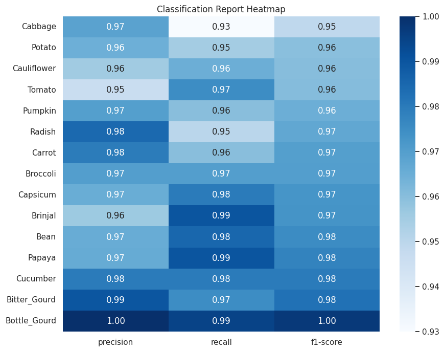

```python
plot_classification_heatmap(cls_df_cnn2)
```

*Things Observed*

### Cohen Kappa Coefficient

```python
y_pred = cnn_model2.predict(X_test_small)
y_pred_classes = np.argmax(y_pred, axis=1)
kappa_cnn2 = cohen_kappa_score(y_test_small, y_pred_classes)
print("Cohen’s Kappa Score:", kappa_cnn2)
```

```
Cohen’s Kappa Score: 0.9685714285714285
```

Adding results to dataframe

```python
results_cnn2['Model Name'] = 'CNN_Baseline2'
results_cnn2['Kappa'] = kappa_cnn2
overall = pd.concat([overall, pd.DataFrame([results_cnn2])], ignore_index=True)
overall
```

|  | Model Name | Epochs | Batch Size | Train Loss | Test Loss | Train Acc | Test Acc | Kappa | Comments |
| --- | --- | --- | --- | --- | --- | --- | --- | --- | --- |
| 0 | Baseline_Dense_Model | 42 | 128 | 0.914943 | 1.486889 | 0.715884 | 0.554000 | 0.527857 | NaN |
| 1 | CNN_Baseline | 52 | 128 | 0.074410 | 0.261325 | 0.976961 | 0.927333 | 0.924643 | NaN |
| 2 | CNN_Baseline2 | 44 | 128 | 0.025112 | 0.111673 | 0.998006 | 0.968000 | 0.968571 | NaN |

*Things Observed*

- From the Cophen Kappa Coefficient, we can see that the model is reliable and good

### Baseline Model 4 Creation (Custom VGG16)

This is how it looks like

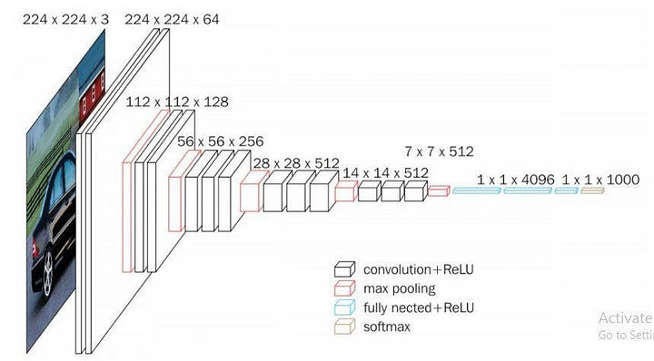

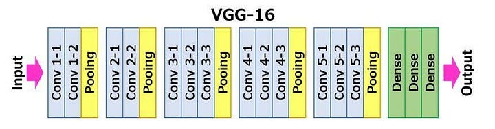

**Vgg Model 16: Developed by Cornell University**

**My Implementation**

- Increase of layers
- Starts at a lower number of filters
- Change in conv block (reduce to 3 from 5)
- Added batch normliasation
- Added L2 regularisation
- Reduce the dropout ratelayer
- More Conv block will be added

```python
def vgg_conv_layer(filters, kernel_size=3, activation='relu', weight_decay=WEIGHT_DECAY):
    return Sequential([
        Conv2D(filters, kernel_size, padding='same', activation=None, kernel_regularizer=l2(weight_decay)),
        BatchNormalization(),
        ReLU() if activation == 'relu' else activation
    ])

def vgg_conv_block(no_layers, filters, activation='relu'):
    block = Sequential()
    for _ in range(no_layers):
        block.add(vgg_conv_layer(filters, activation=activation))
    block.add(MaxPooling2D(pool_size=(2, 2), strides=2))
    return block

class VGGNet(Model):
    def __init__(self, input_shape, num_classes, name='VGGNet_Baseline'):
        super(VGGNet, self).__init__(name=name)
        self.vgg_blocks = [
            vgg_conv_block(2, 32, activation='relu'),
            vgg_conv_block(3, 64, activation='relu'),
            vgg_conv_block(3, 256, activation='relu'),
        ]
        self.global_pool = GlobalAveragePooling2D()
        self.classifier = Sequential([
            Dropout(0.3),
            Dense(num_classes, activation='softmax')
        ])

    def call(self, inputs):
        x = inputs
        for block in self.vgg_blocks:
            x = block(x)
        x = self.global_pool(x)
        return self.classifier(x)

    def build(self, input_shape):
        inputs = Input(shape=(31,31,1))
        model = Model(inputs=inputs, outputs=self.call(inputs), name=self.name)
        return model
```

#### Starting the model

```python
input_shape = (31, 31, 1)
num_classes = 15
vgg = VGGNet(input_shape, num_classes)
vgg_model = vgg.build(input_shape)
optimizer = tf.keras.optimizers.Adam(learning_rate=0.01)
vgg_model.compile(optimizer=optimizer, loss='categorical_crossentropy', metrics=['accuracy'])
vgg_model.summary()
```

```
Model: "VGGNet_Baseline"
_________________________________________________________________
 Layer (type)                Output Shape              Param #
=================================================================
 input_1 (InputLayer)        [(None, 31, 31, 1)]       0

 sequential (Sequential)     (None, 15, 15, 32)        9824

 sequential_3 (Sequential)   (None, 7, 7, 64)          93120

 sequential_7 (Sequential)   (None, 3, 3, 256)         1330944

 global_average_pooling2d (G  (None, 256)              0
 lobalAveragePooling2D)

 sequential_11 (Sequential)  (None, 15)                3855

=================================================================
Total params: 1,437,743
Trainable params: 1,435,695
Non-trainable params: 2,048
_________________________________________________________________
```

#### Running the model

```python
results_vgg, fig_vgg = evaluator.model_evaluate( train_ds, val_ds , vgg_model, base_hparams)
```